# FINAL PROJECT

Nhom 1

2024-12-29

# **Môn:** Xử lý số liệu thống kê

**Lớp:** 22TTH_KDL  
**GV:** Tô Đức Khánh  
**Final Project**

## **Nhóm SV: Nhóm 1**

**Thành viên:**  
- Lê Tuấn Minh Thành - 22280083  
- Hoàng Thái Hoàng - 22280028  
- Hồng Đức Hoàng - 22280029  
- Bạch Ngọc Lê Duy - 22280016  
- Hoàng Minh Hiển - 22280021  
- Nguyễn Phạm Anh Trí - 22110236  
—

# Library

```r
# install.packages('mgcViz')
# install.packages('mice')
# install.packages('Metrics')
# install.packages('e1071')
```

```r
library(car)
```

```r
library(ggplot2)
library(readr)
library(tidyverse)
library(janitor)
library(psych)
library(DataExplorer)
library(carData)
library(leaps)
library(mice)
library(VIM)
library(dplyr)
library(stringr)
library(glmnet)
library(caTools)
library(mgcv)
library(mgcViz)
# library(MASS)
library(caret)
library(Metrics)
library(reshape2)
library(caret)  # Chia dữ liệu và xây dựng mô hình
library(nnet)   # Hồi quy logistic đa lớp
library(e1071)  # Naive Bayes
library(pROC)
```

# *Tiền xử lý dữ liệu*

```r
# Đọc dataset và làm sạch tên cột
fifa_data = read_csv("fifa_eda_stats.csv", na = c("", "NA", "N/A")) |> clean_names()
# Hàm chuyển đổi dạng tiền tệ sang số
currency_to_numeric <- function(x) {
  x <- gsub("€", "", x)
  x <- gsub("M", "e6", x)
  x <- gsub("K", "e3", x)
  return(as.numeric(eval(parse(text = x))))
}

# Đổi dạng các cột value, wage và release_clause
fifa_data$value <- sapply(fifa_data$value, currency_to_numeric)
fifa_data$wage <- sapply(fifa_data$wage, currency_to_numeric)
fifa_data$release_clause <- sapply(fifa_data$release_clause, currency_to_numeric)

# Xử lý chiều cao (height) và cân nặng (weight)
fifa_data$height <- as.numeric(gsub("'", ".", fifa_data$height))
fifa_data$weight <- as.numeric(gsub("lbs", "", fifa_data$weight))

# Loại bỏ các cột không cần thiết
columns_to_drop <- c("loaned_from", "id", "jersey_number", "joined")
fifa_data <- fifa_data %>% select(-all_of(columns_to_drop))
```

```r
# checl na values
colSums(is.na(fifa_data))
```

```
##                     name                      age              nationality
##                        0                        0                        0
##                  overall                potential                     club
##                        0                        0                      241
##                    value                     wage           preferred_foot
##                        0                        0                       48
## international_reputation                weak_foot              skill_moves
##                       48                       48                       48
##                work_rate                body_type                 position
##                       48                       48                       60
##     contract_valid_until                   height                   weight
##                      289                       48                       48
##                 crossing                finishing         heading_accuracy
##                       48                       48                       48
##            short_passing                  volleys                dribbling
##                       48                       48                       48
##                    curve              fk_accuracy             long_passing
##                       48                       48                       48
##             ball_control             acceleration             sprint_speed
##                       48                       48                       48
##                  agility                reactions                  balance
##                       48                       48                       48
##               shot_power                  jumping                  stamina
##                       48                       48                       48
##                 strength               long_shots               aggression
##                       48                       48                       48
##            interceptions              positioning                   vision
##                       48                       48                       48
##                penalties                composure                  marking
##                       48                       48                       48
##          standing_tackle           sliding_tackle                gk_diving
##                       48                       48                       48
##              gk_handling               gk_kicking           gk_positioning
##                       48                       48                       48
##              gk_reflexes           release_clause
##                       48                     1564
```

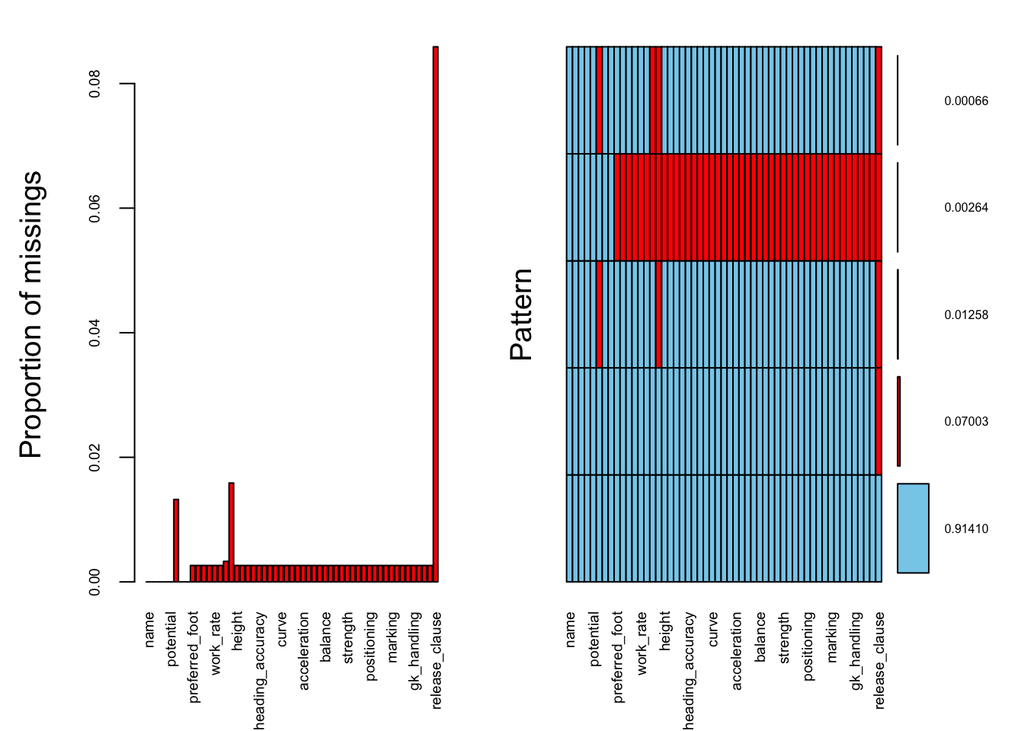

```r
# Kiểm tra xu hướng dữ liệu khuyết
aggr(fifa_data, ylab = c("Proportion of missings", "Pattern"), number = TRUE, cex.axis = 0.6, cex.numbers = 0.5)
```

Ta dễ dàng thấy đa số dữ liệu khuyết đều rất nhỏ, có biến release_clause cao hơn hẳn các biến còn lại nhưng tỷ lệ bé hơn 0.09. Và tỷ lệ khuyết của đa số các biến cùng vị trí nên ta có thể xem xét loại bỏ tất cả dữ liệu khuyết.

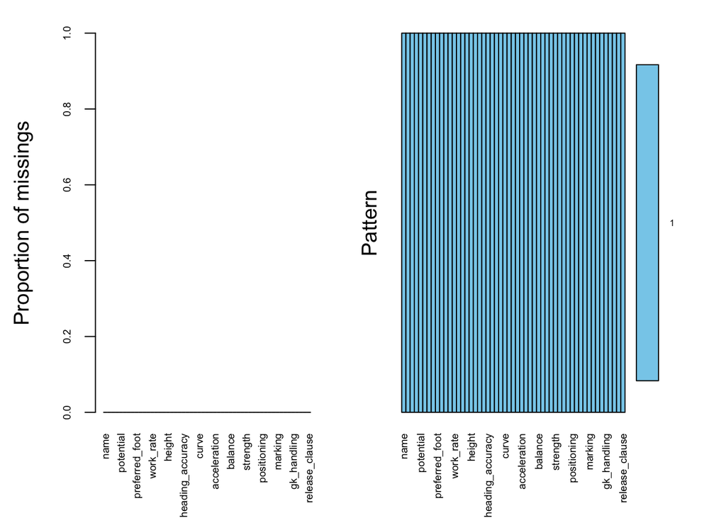

```r
# Xoá tất cả dữ liệu khuyết
fifa_data = na.omit(fifa_data)

# Kiểm tra lại
aggr(fifa_data, ylab = c("Proportion of missings", "Pattern"), number = TRUE, cex.axis = 0.6, cex.numbers = 0.5)
```

Dữ liệu gần như đã clean!

# *Khám phá dữ liệu*

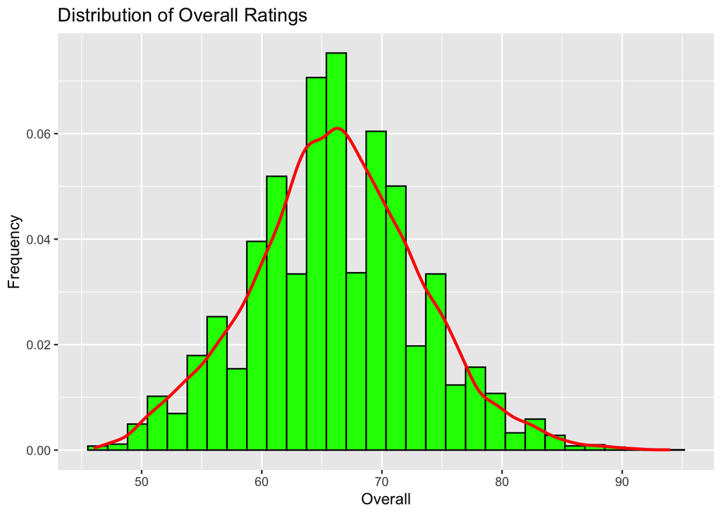

```r
# Biểu đồ phân phối Overall Ratings
ggplot(fifa_data, aes(x = overall)) +
  geom_histogram(aes(y = ..density..), bins = 30, color = "black", fill = "green", alpha = 1) +
  geom_density(alpha = 0.6, color = "red", linewidth = 1) +
  labs(title = "Distribution of Overall Ratings", x = "Overall", y = "Frequency")
```

Biểu đồ overal tuân theo phân phối chuẩn. Đây một tín hiệu tích cực cho bài toán dự đoán.

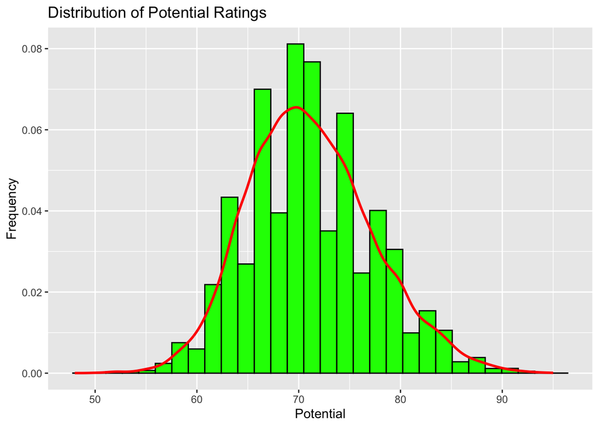

```r
# Biểu đồ phân phối Potential Ratings
ggplot(fifa_data, aes(x = potential)) +
  geom_histogram(aes(y = ..density..), bins = 30, color = "black", fill = "green", alpha = 1) +
  geom_density(alpha = 0.6, color = "red", linewidth = 1) +
  labs(title = "Distribution of Potential Ratings", x = "Potential", y = "Frequency")
```

Vì phân phối chuẩn nên với bài toán classify thì ta phải chuyển potential thành biến phân loại (định tính). Và nếu chia ra 3 class (tiềm năng thấp, vừa, cao) hoặc cao hơn thì sẽ rất khó chia. Vì thể nhóm đề xuất chia làm 2 nhóm để dùng đưa bài toán trở về phân loại nhị phân với class thứ nhất là ít tiềm năng (gán nhãn 0 cho mẫu có potential <= mean) và class thứ 2 là có tiềm năng (gán nhãn 1 cho mẫu có potential > mean)

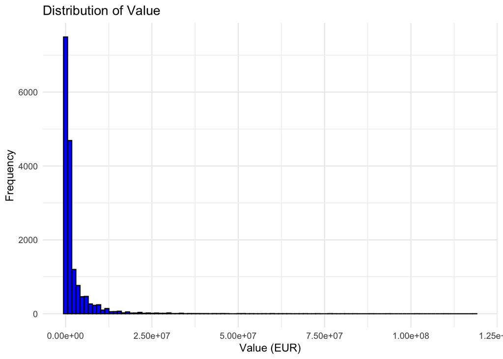

```r
# Biểu đồ phân phối Values
ggplot(fifa_data, aes(x = value)) +
  geom_histogram(bins = 100, fill = "blue", color = "black", alpha = 1) +
  labs(title = "Distribution of Value", x = "Value (EUR)", y = "Frequency") +
  theme_minimal()
```

Biểu đồ bị lệch phải và tồn tại nhiều giá trị ngoại lai (có thể sử dụng giá trị cook).Và đây là biến quan trọng để sử dụng cho bài toán dự đoán số tiền câu lạc bộ phải chi trả.

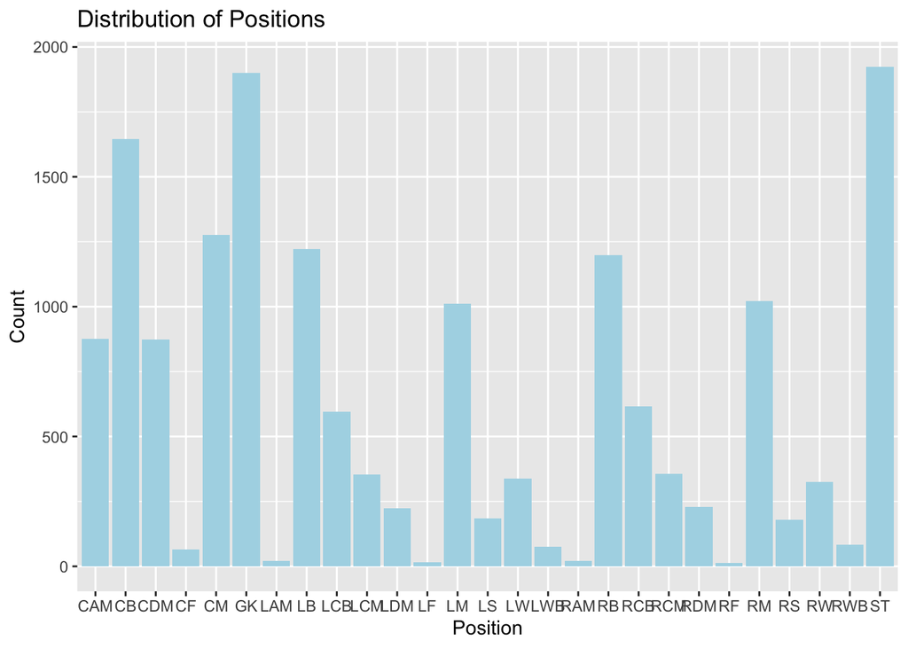

```r
# Biểu đồ số lượng theo vị trí (Position)
ggplot(fifa_data, aes(x = position)) +
  geom_bar(fill = "lightblue") +
  labs(title = "Distribution of Positions", x = "Position", y = "Count")
```

Với Biểu đồ histogram số lượng mẫu theo từng vị trí thì có hiện tượng imbalance nên xem xét các phương pháp xử lý phù hợp. Ở đây chúng em đề xuất group lại thành 4 class chính là: GK (Thủ môn), DF (Cầu thủ phòng ngự), MID (Tiền vệ), FW (Cầu thủ tấn công). Như vậy thì sẽ giải quyết phần nào về vấn đề imbalance và giảm class giúp dễ dàng phân loại hơn.

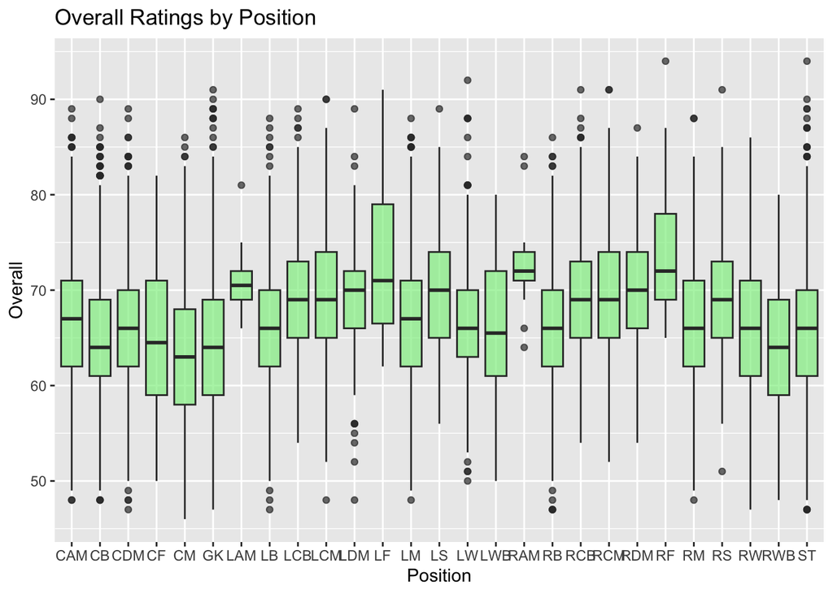

```r
# Boxplot Overall Ratings theo vị trí
ggplot(fifa_data, aes(x = position, y = overall)) +
  geom_boxplot(fill = "lightgreen", alpha = 0.7) +
  labs(title = "Overall Ratings by Position", x = "Position", y = "Overall")
```

*Nhận xét:* - Nếu bài toán phân loại liên quan đến việc dự đoán nhóm cầu thủ (ví dụ: Cao, Trung bình, Thấp), dữ liệu có thể gặp vấn đề mất cân bằng (imbalance).

- Tạo nhóm hợp lý: Có thể chia thành 3 nhóm: Thấp: <60 Trung bình: 60-75 Cao: >75
- Điều này sẽ giúp bài toán phân loại trở nên rõ ràng và dễ huấn luyện hơn. Nhưng chúng em không tiếp cận với bài toán này.

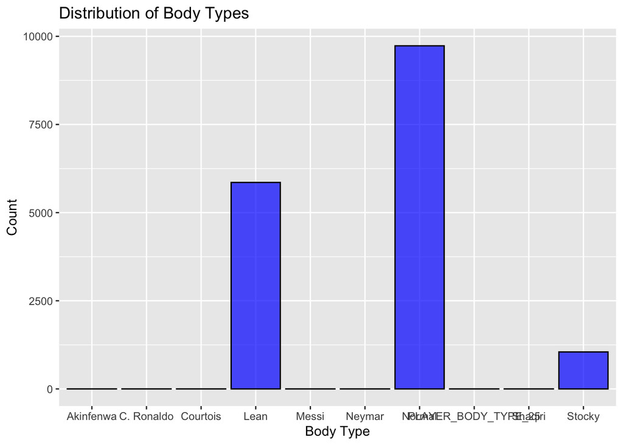

```r
# Phân phối theo Body Type
ggplot(fifa_data, aes(x = body_type)) +
  geom_bar(color = "black", fill = "blue", alpha = 0.7) +
  labs(title = "Distribution of Body Types", x = "Body Type", y = "Count")
```

Dễ dàng thấy có 3 class chính là Lean, Normal và Stocky, còn lại gần như chỉ có 1 sample. 3 class chính cũng bị imbalance nên sử dụng để làm bài toán phân loại có vẽ không hợp lý và không có ích với việc giúp câu lạc bộ đưa ra quyết định. Và theo lý thuyết thì cũng khó để sử dụng biến này để đưa vào mô hình làm biến.

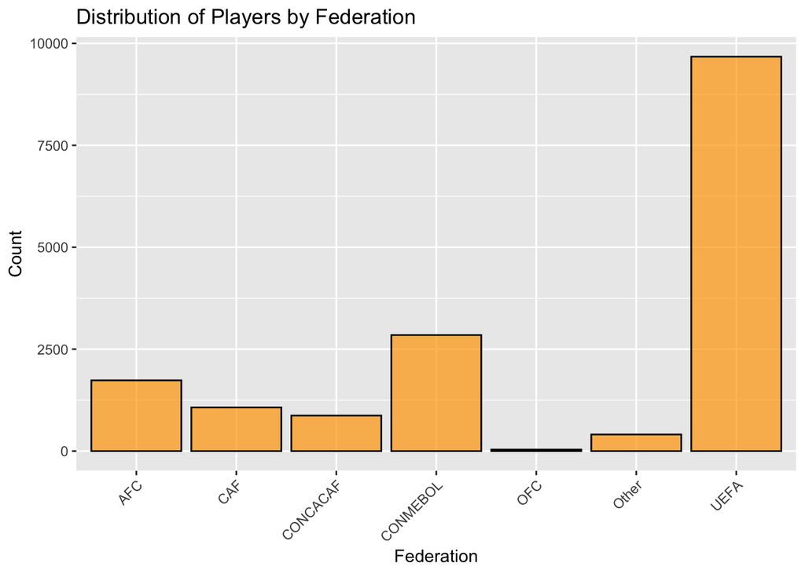

```r
# Phân phối nationality theo các liên đoàn bóng đá
federations <- list(
  UEFA = c("Spain", "Germany", "France", "England", "Italy", "Portugal", "Netherlands", "Belgium", "Sweden", "Russia", "Switzerland", "Croatia", "Poland", "Denmark", "Wales", "Slovakia", "Bosnia Herzegovina", "Serbia", "Austria", "Greece", "Finland", "Montenegro", "Armenia", "Norway", "Czech Republic", "Scotland", "Ukraine", "Iceland", "Albania", "Hungary", "Republic of Ireland", "Romania", "Northern Ireland", "Estonia", "FYR Macedonia", "Bulgaria", "Kosovo", "Georgia", "Belarus", "Moldova", "Lithuania", "Luxembourg", "Liechtenstein", "Latvia", "Azerbaijan", "Faroe Islands", "Andorra", "Malta"),
  CONMEBOL = c("Brazil", "Argentina", "Colombia", "Uruguay", "Chile", "Ecuador", "Paraguay", "Venezuela", "Peru", "Bolivia"),
  CONCACAF = c("Mexico", "United States", "Costa Rica", "Jamaica", "Dominican Republic", "Honduras", "Canada", "Curacao", "Trinidad & Tobago", "Panama", "Cuba", "Haiti", "Grenada", "St Kitts Nevis", "El Salvador", "Antigua & Barbuda", "Guatemala", "Nicaragua", "Barbados", "Puerto Rico"),
  CAF = c("Senegal", "Nigeria", "Egypt", "Morocco", "Algeria", "Gabon", "Ghana", "Central African Rep.", "DR Congo", "Ivory Coast", "Tunisia", "South Africa", "Guinea", "Kenya", "Cape Verde", "Mali", "Cameroon", "Burkina Faso", "Zimbabwe", "Angola", "Equatorial Guinea", "Guinea Bissau", "Madagascar", "Tanzania", "Gambia", "Benin", "Congo", "Mozambique", "Sierra Leone", "Zambia", "Chad", "Comoros", "Libya", "Eritrea", "Burundi", "Namibia", "Sudan", "Rwanda", "Mauritania", "Botswana", "Liberia", "Niger", "Ethiopia"),
  AFC = c("Japan", "Korea Republic", "Iran", "Australia", "Saudi Arabia", "China PR", "Uzbekistan", "Syria", "Iraq", "India", "Lebanon", "Jordan", "Qatar", "Afghanistan", "Hong Kong", "Indonesia", "Thailand", "Kuwait"),
  OFC = c("New Zealand", "Fiji", "New Caledonia", "Guam")
)

fifa_data$federation <- sapply(fifa_data$nationality, function(x) {
  found <- "Other"
  for (fed in names(federations)) {
    if (x %in% federations[[fed]]) {
      found <- fed
      break
    }
  }
  return(found)
})

ggplot(fifa_data, aes(x = federation)) +
  geom_bar(color = "black", fill = "orange", alpha = 0.7) +
  labs(title = "Distribution of Players by Federation", x = "Federation", y = "Count") +
  theme(axis.text.x = element_text(angle = 45, hjust = 1))
```

Nhóm xem xét về việc sử dụng biến nationality (quốc gia) để dùng làm biến trong một mô hình nào đó, tuy nhiên vì đây là biến định tính và số lượng class rất nhiền nên khó xử lý. Vì thế chúng em nhóm lại chia thành các liên đoàn bóng đá. Và biểu đồ cho thấy các class theo liên đoàn bóng đá cũng khá bị imbalance nhưng có thể xử lý được bằng cách loại bỏ “OFC”. Và có thể dùng cho bài toán phân loại liên đoàn. Nhưng nhóm không tiếp cận bài toán này.

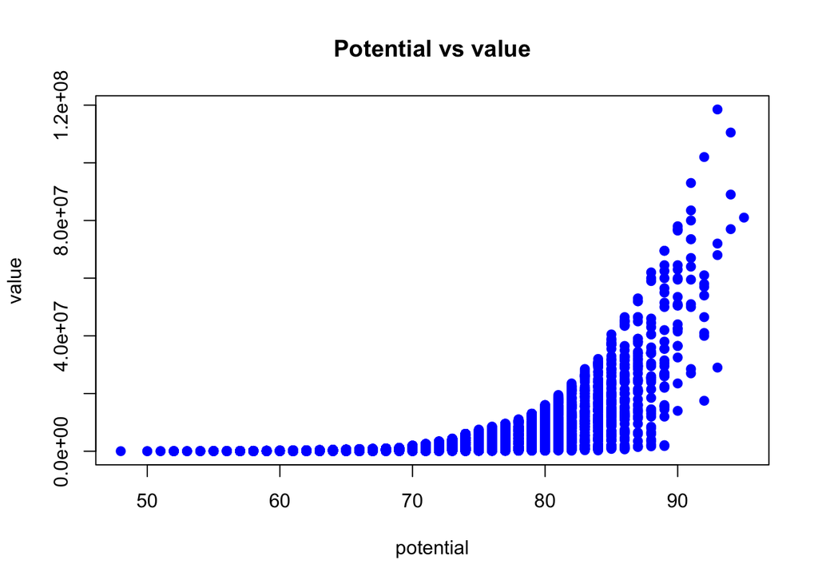

```r
plot(fifa_data$potential, fifa_data$value, main="Potential vs value",
     xlab="potential", ylab="value",
     pch=19, col="blue")
```

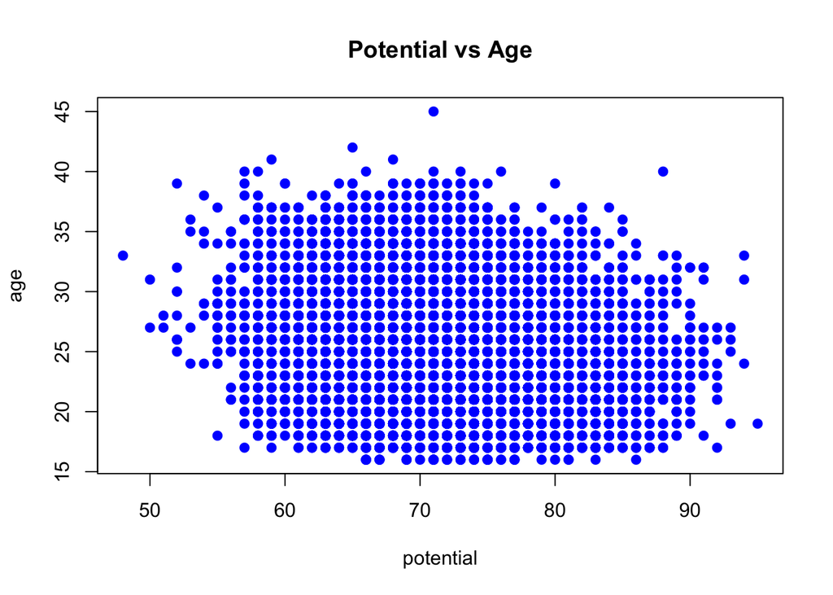

```r
plot(fifa_data$potential, fifa_data$age, main="Potential vs Age",
     xlab="potential", ylab="age",
     pch=19, col="blue")
```

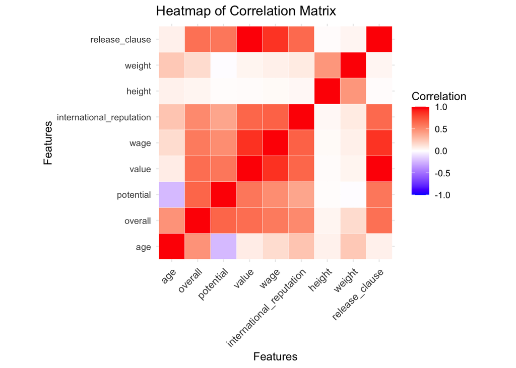

```r
# Tạo ma trận tương quan và bỏ các feature kỹ thuật
tech_features = c("weak_foot", "skill_moves", "crossing", "finishing", "heading_accuracy",
                   "short_passing", "volleys", "dribbling", "curve", "long_passing",
                   "ball_control", "acceleration", "sprint_speed", "agility",
                   "reactions", "balance", "shot_power", "jumping", "stamina", "strength",
                   "long_shots", "aggression", "interceptions", "positioning", "vision",
                   "penalties", "composure", "marking", "standing_tackle", "sliding_tackle",
                   "gk_diving", "gk_handling", "gk_kicking", "gk_positioning", "gk_reflexes",
                   "fk_accuracy")

correlation_matrix = fifa_data %>%
  dplyr::select(-all_of(tech_features)) %>%
  dplyr::select(where(is.numeric)) %>%
  cor(use = "complete.obs")

melted_corr = melt(correlation_matrix)
ggplot(melted_corr, aes(Var1, Var2, fill = value)) +
  geom_tile(color = "white") +
  scale_fill_gradient2(low = "blue", high = "red", mid = "white",
                       midpoint = 0, limit = c(-1,1), space = "Lab",
                       name="Correlation") +
  theme_minimal() +
  theme(axis.text.x = element_text(angle = 45, vjust = 1,
                                   size = 10, hjust = 1)) +
  coord_fixed() +
  labs(title = "Heatmap of Correlation Matrix", x = "Features", y = "Features")
```

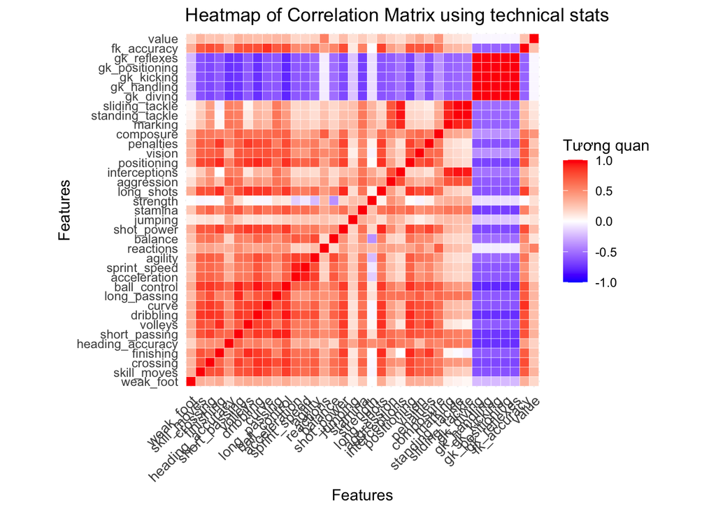

```r
correlation_matrix_tech <- fifa_data %>%
  dplyr::select(all_of(tech_features) | value) %>%
  cor(use = "complete.obs")

# Biểu diễn ma trận tương quan thông số kỹ thuật (demo)
melted_corr_tech <- melt(correlation_matrix_tech)
ggplot(melted_corr_tech, aes(Var1, Var2, fill = value)) +
  geom_tile(color = "white") +
  scale_fill_gradient2(low = "blue", high = "red", mid = "white",
                       midpoint = 0, limit = c(-1,1), space = "Lab",
                       name="Tương quan") +
  theme_minimal() +
  theme(axis.text.x = element_text(angle = 45, vjust = 1,
                                   size = 10, hjust = 1)) +
  coord_fixed() +
  labs(title = "Heatmap of Correlation Matrix using technical stats", x = "Features", y = "Features")
```

Tương tự như biểu đồ trên, có rất nhiều biến có hệ số tương quan cao và ta cần xử lý chi tiết hơn thay vì đọc biểu đồ này.

# *Xây dựng bài toán*

## Bài toán 1: Dự đoán số tiền (Value) câu lạc bộ phải chi trả

> Với bài toán này nhóm em chia ra làm 2 phương pháp tiếp cận: dự đoán value dựa trên các biến nontechnical (không phải biến kỹ thuật) và trên các biến technical (các biến đánh giá chỉ số kỹ thuật)

### Cách tiếp cận 1: Dự đoán value dựa trên các biến Nontechnical

#### Xây dựng mô hình

```r
# Tạo mô hình hồi quy tuyến tính đa biến với Y = value và X là các biến nontechnical
m_value_non_tech = lm(value ~ age + overall + wage + international_reputation
                       + release_clause, fifa_data)
```

vì 2 biến overall và potential có khả năng tương quan cao nên không đưa vào mô hình cùng lúc để tránh đa cộng tuyến

#### Lựa chọn mô hình

```r
# tìm tập biến tốt nhất cho mô hình
out_subset_m_value_non_tech <- regsubsets(x = value ~ age + overall + wage + international_reputation
                                          + release_clause,
                                          data = fifa_data, nvmax = 5, method = "exhaustive")
summary(out_subset_m_value_non_tech)
```

```
## Subset selection object
## Call: regsubsets.formula(x = value ~ age + overall + wage + international_reputation +
##     release_clause, data = fifa_data, nvmax = 5, method = "exhaustive")
## 5 Variables  (and intercept)
##                          Forced in Forced out
## age                          FALSE      FALSE
## overall                      FALSE      FALSE
## wage                         FALSE      FALSE
## international_reputation     FALSE      FALSE
## release_clause               FALSE      FALSE
## 1 subsets of each size up to 5
## Selection Algorithm: exhaustive
##          age overall wage international_reputation release_clause
## 1  ( 1 ) " " " "     " "  " "                      "*"
## 2  ( 1 ) " " " "     " "  "*"                      "*"
## 3  ( 1 ) " " "*"     " "  "*"                      "*"
## 4  ( 1 ) " " "*"     "*"  "*"                      "*"
## 5  ( 1 ) "*" "*"     "*"  "*"                      "*"
```

```r
# chỉ số Mallows' Cp càng nhỏ -> mô hình càng tốt
sum_out_subset_m_value_non_tech <- summary(out_subset_m_value_non_tech)
sum_out_subset_m_value_non_tech$cp
```

```
## [1] 1768.172387  639.163879  212.815508    4.058525    6.000000
```

Từ kết quả trên ta thấy tập kết quả chứa 4 biến là tốt nhất. Ta xây dựng lại mô hình với 4 biến overall, wage, international_reputation và release_clause

```r
m_value_non_tech = lm(value ~ overall + wage + international_reputation
                       + release_clause, fifa_data)
```

Tính sai số cho mô hình

```r
# Residuals
res <- residuals(m_value_non_tech)

# SSE
SSE <- sum(res^2)

# MSE
MSE <- SSE / length(res)

# RMSE
RMSE <- sqrt(MSE)

# R-squared
r_squared <- summary(m_value_non_tech)$r.squared

# RSE
RSE <- sqrt(SSE / (length(m_value_non_tech) - length(coef(m_value_non_tech)) - 1))

# In kết quả
cat("SSE: ", SSE, "\n")
```

```
## SSE:  5.544407e+15
```

```r
cat("MSE: ", MSE, "\n")
```

```
## MSE:  333137488534
```

```r
cat("RMSE: ", RMSE, "\n")
```

```
## RMSE:  577180.6
```

```r
cat("R-squared: ", r_squared, "\n")
```

```
## R-squared:  0.9898197
```

```r
cat("RSE: ", RSE, "\n")
```

```
## RSE:  30398485
```

Hệ số R-squared = 0.9898, cho thấy mô hình giải thích được 98.98% biến thiên trong giá trị chuyển nhượng

#### Chẩn đoán cho mô hình

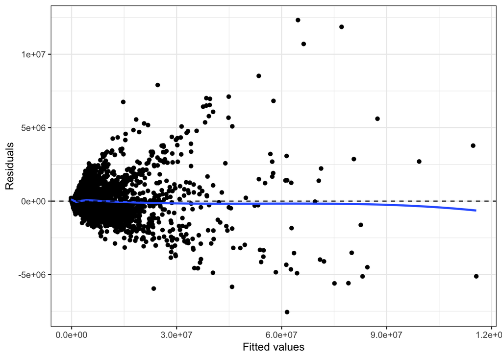

```r
# kiểm tra tính tuyến tính
ggplot(data = m_value_non_tech, mapping = aes(x = .fitted, y = .resid)) +
  geom_point() +
  geom_smooth(method = "loess", se = FALSE) +
  geom_hline(yintercept = 0, linetype = "dashed") +
  labs(x = "Fitted values", y = "Residuals") +
  theme_bw()
```

Đường màu xanh không hoàn toàn khớp với đường nét đứt (y = 0) mà có xu hướng cong nhẹ ở vùng có giá trị dự đoán cao. Chứng tỏ giả định về tính tuyến tính của mô hình là chưa phù hợp

##### kiểm tra tính đồng nhất phương sai

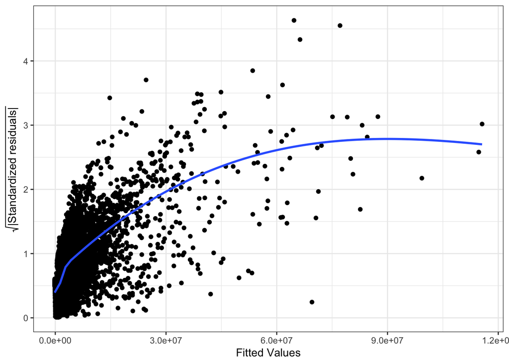

```r
ggplot(data = m_value_non_tech, mapping = aes(x = .fitted, y = sqrt(abs(.stdresid)))) +
  geom_point(na.rm = TRUE) +
  geom_smooth(method = "loess", se = FALSE, na.rm = TRUE) +
  labs(x = "Fitted Values", y = expression(sqrt("|Standardized residuals|"))) +
  theme_bw()
```

Đường màu xanh có xu hướng đi lên khi giá trị dự đoán tăng. Điều này chứng tỏ phương sai phần dư không đồng nhất mà tăng dần theo giá trị dự đoán.

##### kiểm tra các giá trị ngoại lai

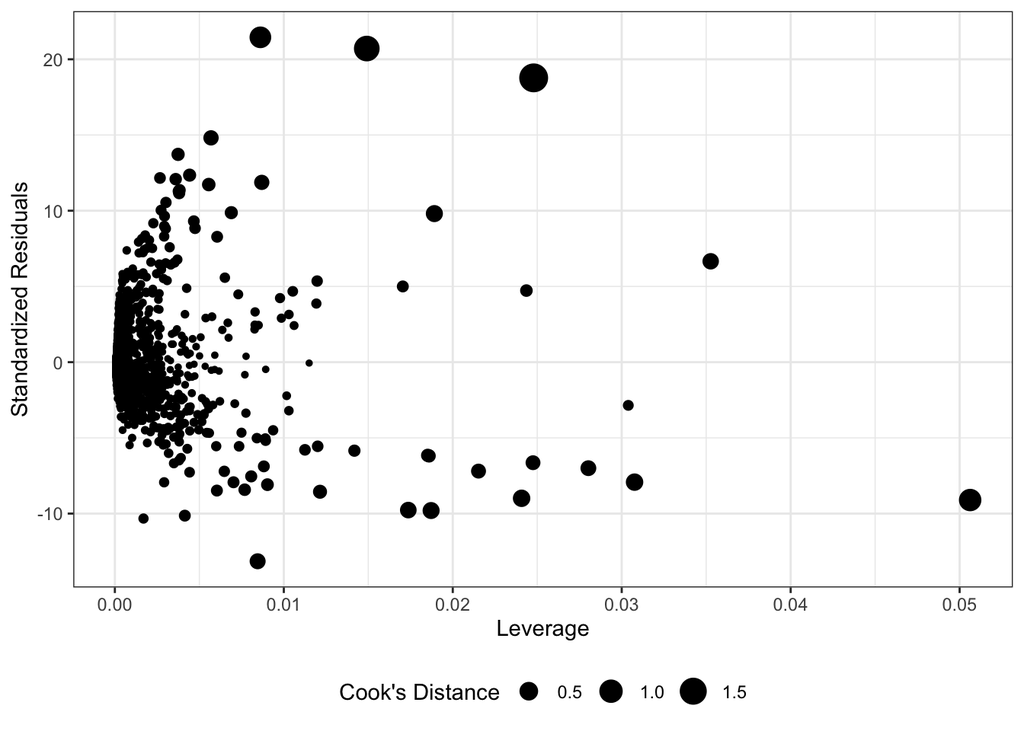

```r
ggplot(m_value_non_tech, aes(.hat, .stdresid)) +
  geom_point(aes(size = .cooksd)) +
  xlab("Leverage") + ylab("Standardized Residuals") +
  scale_size_continuous("Cook's Distance", range = c(1, 6)) +
  theme_bw() +
  theme(legend.position = "bottom")
```

Kiểm tra xem các điểm có Cook’s Distance lớn chiếm bao nhiêu phần trăm dữ liệu

```r
cooks_D_md_m_value_non_tech <- cooks.distance(m_value_non_tech)

count_001 <- sum(cooks_D_md_m_value_non_tech >= 0.5)
count_002 <- sum(cooks_D_md_m_value_non_tech >= 1.0)
count_003 <- sum(cooks_D_md_m_value_non_tech >= 1.5)

# Tính phần trăm so với tổng số dữ liệu
total_count <- length(cooks_D_md_m_value_non_tech)
percent_001 <- (count_001 / total_count) * 100
percent_002 <- (count_002 / total_count) * 100
percent_003 <- (count_003 / total_count) * 100

cat("Phần trăm của dữ liệu có Cook's Distance >= 0.5 là:", percent_001, "%\n")
```

```
## Phần trăm của dữ liệu có Cook's Distance >= 0.5 là: 0.02403413 %
```

```r
cat("Phần trăm của dữ liệu có Cook's Distance >= 1.0 là:", percent_002, "%\n")
```

```
## Phần trăm của dữ liệu có Cook's Distance >= 1.0 là: 0.01201706 %
```

```r
cat("Phần trăm của dữ liệu có Cook's Distance >= 1.5 là:", percent_003, "%\n")
```

```
## Phần trăm của dữ liệu có Cook's Distance >= 1.5 là: 0.006008532 %
```

các điểm có cook’s distance >= 0.5 chỉ chiếm khoảng 0.02% tổng dữ liệu nên không ảnh hưởng đáng kể đến mô hình

##### kiểm tra hiện tượng đa cộng tuyến

```r
library(car)
vif(m_value_non_tech)
```

```
##                  overall                     wage international_reputation
##                 1.672385                 4.197567                 1.943834
##           release_clause
##                 4.148991
```

vif của tất cả các biến đều nhỏ hơn 5 -> không có hiện tượng đa cộng tuyến

#### Mở rộng mô hình

##### Model GLM

Mô hình GLM sử dụng phân phối Gamma để mô hình hóa cho dữ liệu bị lệch phải

Vì hàm Gamma không chấp nhận giá trị 0 nên ta xem xét các giá trị 0 chiếm bao nhiêu phần trăm trong value

```r
# Số lượng giá trị bằng 0
num_zeros <- sum(fifa_data$value == 0)

# Tổng số giá trị
total_values <- length(fifa_data$value)

# Tính tỷ lệ phần trăm
percent_zeros <- (num_zeros / total_values) * 100
cat("Phần trăm các giá trị bé hơn hoặc bằng 0 trong biến Value là:", percent_zeros, "%\n")
```

```
## Phần trăm các giá trị bé hơn hoặc bằng 0 trong biến Value là: 0 %
```

Không tồn tại các giá trị có value bằng 0 nên ta có thể áp dụng mô hình GLM

```r
# family: kiểu phân phối
# link: hàm liên kết mặc định
m_value_non_tech_glm <- glm(value ~ overall + wage + international_reputation
                      + release_clause, family = Gamma(link = "log"), data = fifa_data)
summary(m_value_non_tech_glm)
```

```
##
## Call:
## glm(formula = value ~ overall + wage + international_reputation +
##     release_clause, family = Gamma(link = "log"), data = fifa_data)
##
## Coefficients:
##                            Estimate Std. Error t value Pr(>|t|)
## (Intercept)               2.318e+00  3.235e-02   71.64   <2e-16 ***
## overall                   1.740e-01  5.019e-04  346.64   <2e-16 ***
## wage                     -2.801e-06  2.503e-07  -11.19   <2e-16 ***
## international_reputation -2.405e-01  9.514e-03  -25.27   <2e-16 ***
## release_clause            3.126e-08  4.983e-10   62.74   <2e-16 ***
## ---
## Signif. codes:  0 '***' 0.001 '**' 0.01 '*' 0.05 '.' 0.1 ' ' 1
##
## (Dispersion parameter for Gamma family taken to be 0.1231074)
##
##     Null deviance: 37127.5  on 16642  degrees of freedom
## Residual deviance:  2773.8  on 16638  degrees of freedom
## AIC: 470347
##
## Number of Fisher Scoring iterations: 14
```

Kiểm tra lại các giả định một lần nữa bằng biểu đồ Residual - fitted

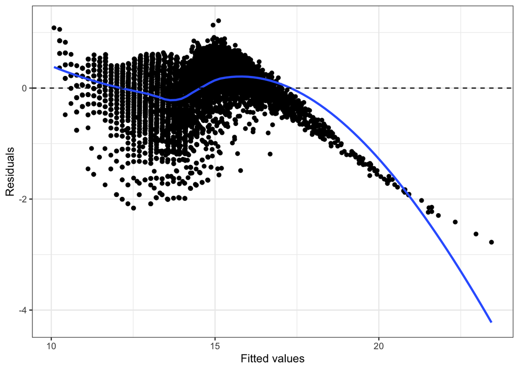

```r
ggplot(data = m_value_non_tech_glm, mapping = aes(x = .fitted, y = .resid)) +
geom_point() +
geom_smooth(method = "loess", se = FALSE) +
geom_hline(yintercept = 0, linetype = "dashed") +
labs(x = "Fitted values", y = "Residuals") +
theme_bw()
```

Phần dư trong biểu đồ trên giảm dần theo chiều tăng của biến đáp ứng chứng tỏ hiện tượng mất đồng nhất phương sai vẫn còn tồn tại. Mô hình GLM có lẽ không hoạt động tốt trên tập dữ liệu này

##### Model GAM

GAM có thể áp dụng cho toàn bộ biến hoặc một số biến trong mô hình. Ta chỉ có 4 biến đầu vào nên ta sẽ kiểm tra tính tuyến tính từng phần của từng biến bằng biểu đồ thặng dư từng phần

```r
# tính hệ số ước lượng của tất cả các biến
terms_m_value_non_tech <- predict(m_value_non_tech, type = "terms")

# thặng dư từng phần của tất cả các biến
partial_resid_m_value_non_tech <- residuals(m_value_non_tech, type = "partial")
```

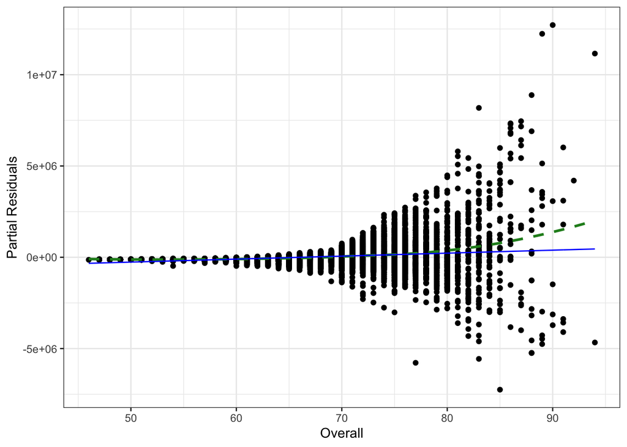

```r
# overall
data_part_resid_overall <- tibble(
  overall = fifa_data$overall,
  terms_overall = terms_m_value_non_tech[, "overall"],
  partial_resid_overall = partial_resid_m_value_non_tech[, "overall"]
)
ggplot(data_part_resid_overall, mapping = aes(overall, partial_resid_overall)) +
  geom_point() +
  geom_smooth(method = "loess", se = FALSE, linetype = "dashed",
              color = "forestgreen") +
  geom_line(aes(x = overall, y = terms_overall), color = "blue") +
  labs(x = "Overall", y = "Partial Residuals") +
  theme_bw()
```

Không có quan hệ tuyến tính giữa overall và value

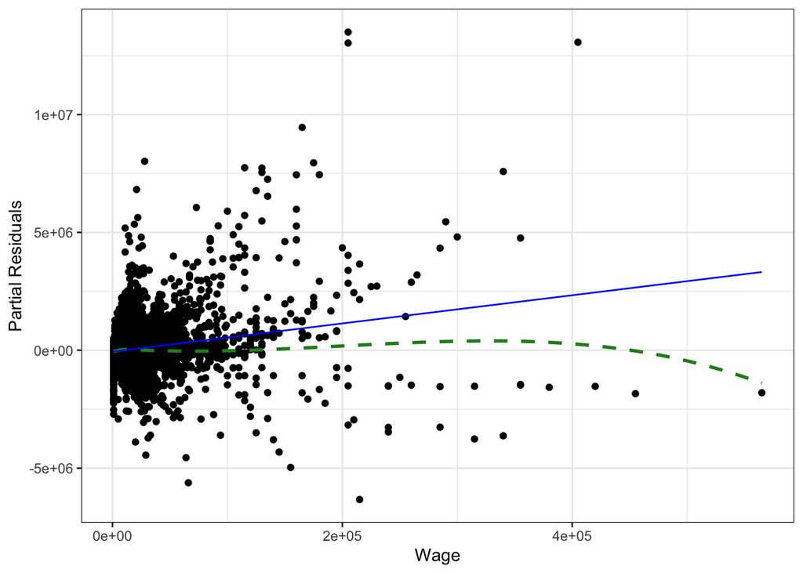

```r
# wage
data_part_resid_wage <- tibble(
  wage = fifa_data$wage,
  terms_wage = terms_m_value_non_tech[, "wage"],
  partial_resid_wage = partial_resid_m_value_non_tech[, "wage"]
)
ggplot(data_part_resid_wage, mapping = aes(wage, partial_resid_wage)) +
  geom_point() +
  geom_smooth(method = "loess", se = FALSE, linetype = "dashed",
              color = "forestgreen") +
  geom_line(aes(x = wage, y = terms_wage), color = "blue") +
  labs(x = "Wage", y = "Partial Residuals") +
  theme_bw()
```

Không có quan hệ tuyến tính giữa wage và value

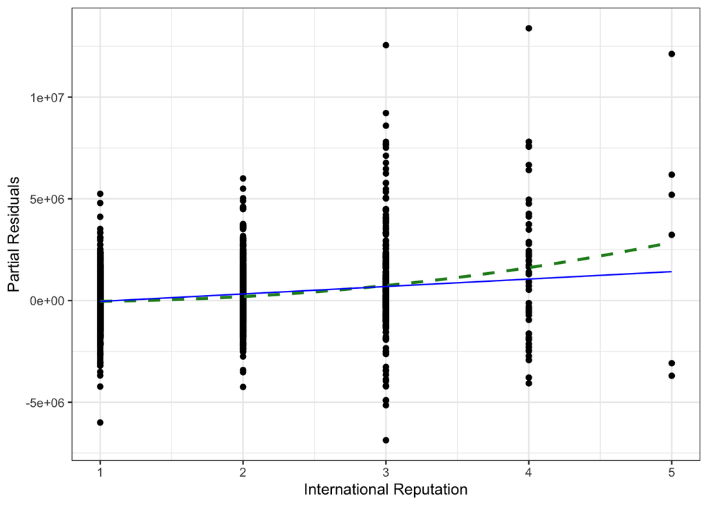

```r
# international_reputation
# đây là biến rời rạc
data_part_resid_inter_rep <- tibble(
  inter_rep = fifa_data$international_reputation,
  terms_inter_rep = terms_m_value_non_tech[, "international_reputation"],
  partial_resid_inter_rep = partial_resid_m_value_non_tech[, "international_reputation"]
)
ggplot(data_part_resid_inter_rep, mapping = aes(inter_rep, partial_resid_inter_rep)) +
  geom_point() +
  geom_smooth(method = "loess", se = FALSE, linetype = "dashed",
              color = "forestgreen", span = 1) +
  geom_line(aes(x = inter_rep, y = terms_inter_rep), color = "blue") +
  labs(x = "International Reputation", y = "Partial Residuals") +
  theme_bw()
```

Không quan hệ tuyến tính giữa international reputation và value

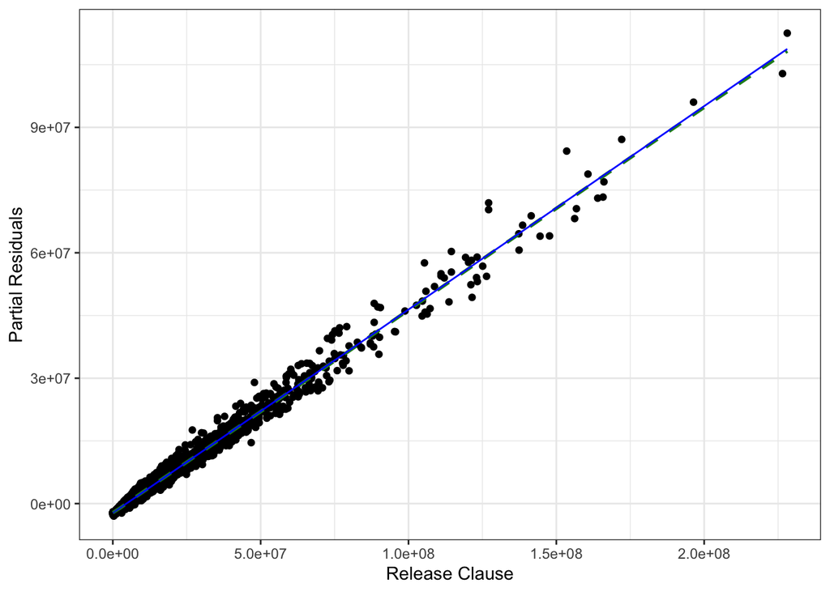

```r
# release_clause
data_part_resid_rel_cl <- tibble(
  rel_cl = fifa_data$release_clause,
  terms_rel_cl = terms_m_value_non_tech[, "release_clause"],
  partial_resid_rel_cl = partial_resid_m_value_non_tech[, "release_clause"]
)
ggplot(data_part_resid_rel_cl, mapping = aes(rel_cl, partial_resid_rel_cl)) +
  geom_point() +
  geom_smooth(method = "loess", se = FALSE, linetype = "dashed",
              color = "forestgreen") +
  geom_line(aes(x = rel_cl, y = terms_rel_cl), color = "blue") +
  labs(x = "Release Clause", y = "Partial Residuals") +
  theme_bw()
```

Có quan hệ tuyến tính giữa release clause và value

```r
m_value_non_tech_gam = gam(value ~ s(overall) + s(wage) + s(international_reputation, k = 5)
                      + release_clause, data = fifa_data)
summary(m_value_non_tech_gam)
```

```
##
## Family: gaussian
## Link function: identity
##
## Formula:
## value ~ s(overall) + s(wage) + s(international_reputation, k = 5) +
##     release_clause
##
## Parametric coefficients:
##                 Estimate Std. Error t value Pr(>|t|)
## (Intercept)    3.163e+05  6.520e+03    48.5   <2e-16 ***
## release_clause 4.638e-01  1.080e-03   429.5   <2e-16 ***
## ---
## Signif. codes:  0 '***' 0.001 '**' 0.01 '*' 0.05 '.' 0.1 ' ' 1
##
## Approximate significance of smooth terms:
##                               edf Ref.df      F p-value
## s(overall)                  5.026  5.870 253.61  <2e-16 ***
## s(wage)                     2.373  2.801  43.79  <2e-16 ***
## s(international_reputation) 1.057  1.076  41.25  <2e-16 ***
## ---
## Signif. codes:  0 '***' 0.001 '**' 0.01 '*' 0.05 '.' 0.1 ' ' 1
##
## Rank: 15/24
## R-sq.(adj) =  0.991   Deviance explained = 99.1%
## GCV = 3.0013e+11  Scale est. = 2.9994e+11  n = 16643
```

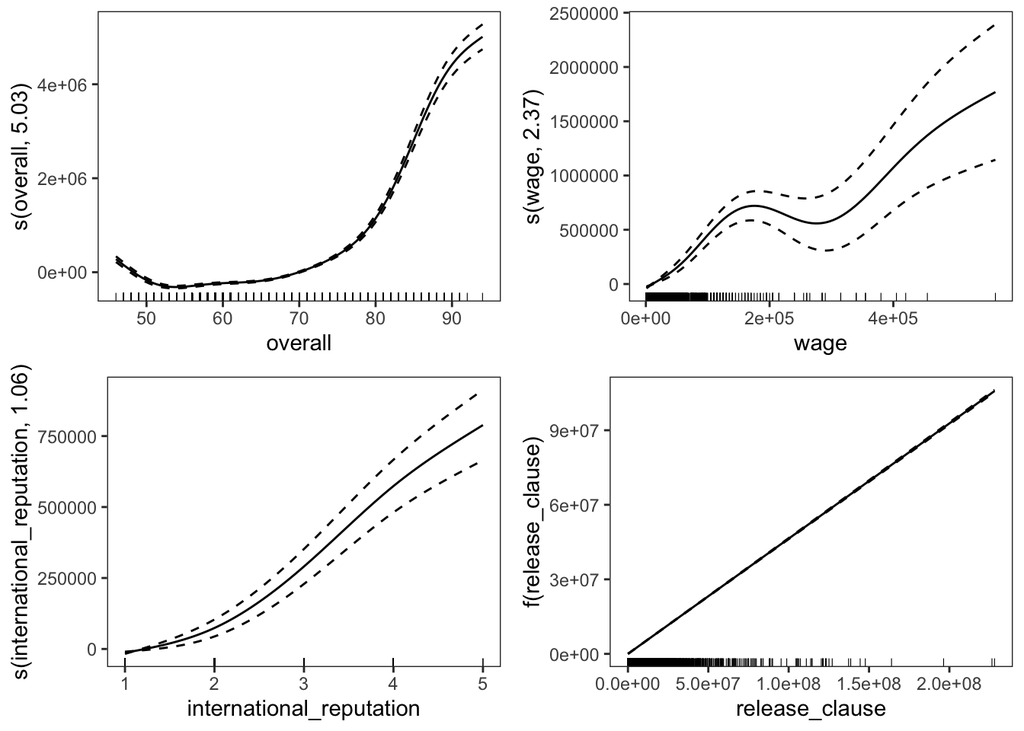

```r
# Tính hệ số ước lượng cho từng biến
terms_m_value_non_tech_gam = predict(m_value_non_tech_gam, type = "terms")

# Tính thặng dư từng phần
partial_resid_m_value_non_tech_gam = residuals(m_value_non_tech_gam, type = "working") + terms_m_value_non_tech_gam

# Vẽ hàm trơn được ước lượng
viz_m_value_non_tech_gam = getViz(m_value_non_tech_gam)
print(plot(viz_m_value_non_tech_gam, allTerms = TRUE), pages = 1)
```

Từ 4 biểu đồ trên ta có thể thấy hệ số ước lượng của các biến (đường nét liền) luôn nằm giữa và không quá xa khoảng tin cậy (2 đường nét đứt). Điều này chừng tỏ mô hình có độ ổn định cao và các kết quả ước lượng đáng tin cậy

```r
set.seed(123)  # Để đảm bảo kết quả có thể tái tạo

# Chia tập dữ liệu theo tỷ lệ 70% train, 30% test
train_index <- sample(1:nrow(fifa_data), 0.7 * nrow(fifa_data))
train_data <- fifa_data[train_index, ]
test_data <- fifa_data[-train_index, ]
```

```r
# Dự đoán giá trị trên tập kiểm tra
predictions_gam <- predict(m_value_non_tech_gam, newdata = test_data)

# Đánh giá mô hình: tính R-squared (R²) và RMSE (Root Mean Squared Error)
library(Metrics)

# Tính R² và RMSE
r_squared <- 1 - sum((test_data$value - predictions_gam)^2) / sum((test_data$value - mean(test_data$value))^2)
rmse_value <- rmse(test_data$value, predictions_gam)

# In kết quả đánh giá
cat("R-squared: ", r_squared, "\n")
```

```
## R-squared:  0.9907223
```

```r
cat("RMSE: ", rmse_value, "\n")
```

```
## RMSE:  560051
```

```r
mean_value <- mean(fifa_data$value)
rmse_ratio <- rmse_value / mean_value
cat("RMSE/Mean: ", rmse_ratio, "\n")
```

```
## RMSE/Mean:  0.2292785
```

Dự đoán của mô hình có mức sai số trung bình khá nhỏ so với giá trị trung bình thực tế. Chứng tỏ rằng mô hình dự đoán khá chính xác so với giá trị thực tế

### Cách tiếp cận 2: Dự đoán value dựa trên các biến Technical

#### Tiền xử lý

```r
# Group theo position thành làm 4 class chính như đã giải thích ở trên:
# GK (Thủ môn), DF (Cầu thủ phòng ngự), MID (Tiền vệ), FW (Cầu thủ tấn công)

numeric_fifa_data = fifa_data %>% dplyr::select(all_of(tech_features) | value)

position_mapping = list(
  Goalkeeper = c("GK"),
  Defender = c("CB", "LCB", "RCB", "LB", "RB", "LWB", "RWB"),
  Midfielder = c("CDM", "CM", "LCM", "RCM", "CAM", "LM", "RM", "LDM", "RDM", "LAM", "RAM"),
  Forward = c("CF", "ST", "LS", "RS", "RF", "LF", "LW", "RW")
)

# Tạo cột mới broad_position
fifa_data$broad_position = NA
for (broad_pos in names(position_mapping)) {
   fifa_data$broad_position[fifa_data$position %in% position_mapping[[broad_pos]]] = broad_pos
}

gk_data = numeric_fifa_data[fifa_data$broad_position == "Goalkeeper", ]
df_data = numeric_fifa_data[fifa_data$broad_position == "Defender", ]
mid_data = numeric_fifa_data[fifa_data$broad_position == "Midfielder", ]
fw_data = numeric_fifa_data[fifa_data$broad_position == "Forward", ]
```

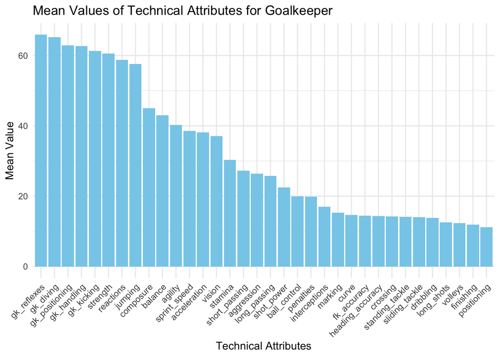

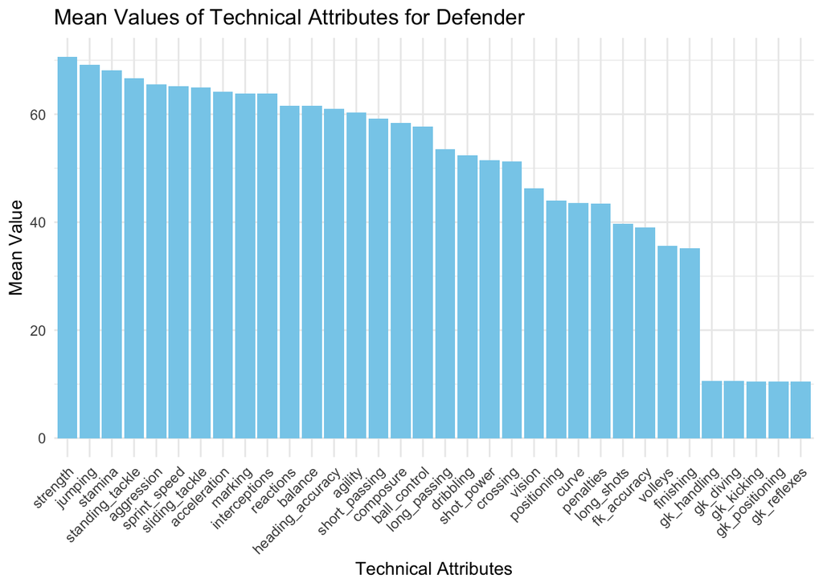

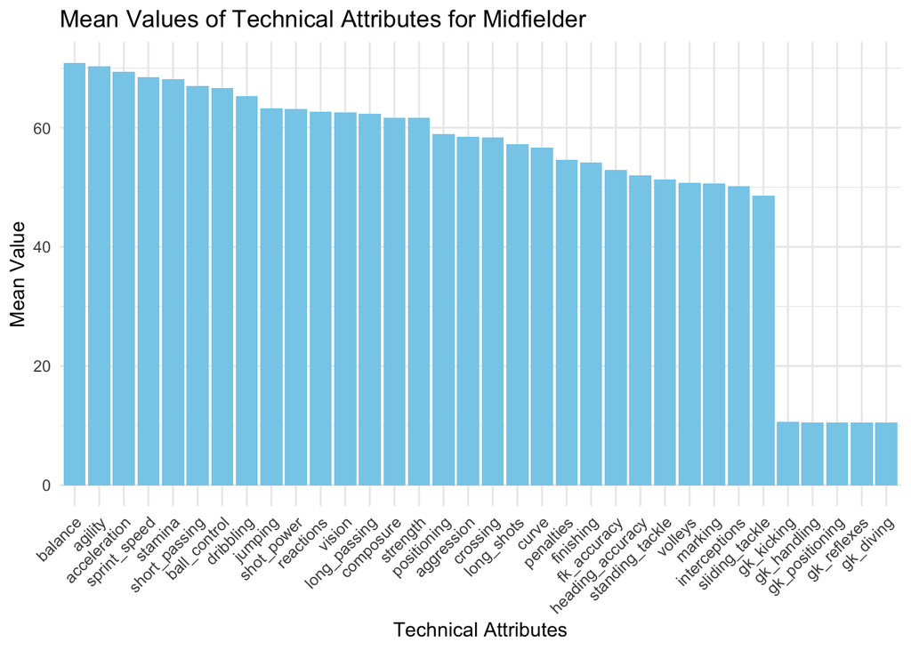

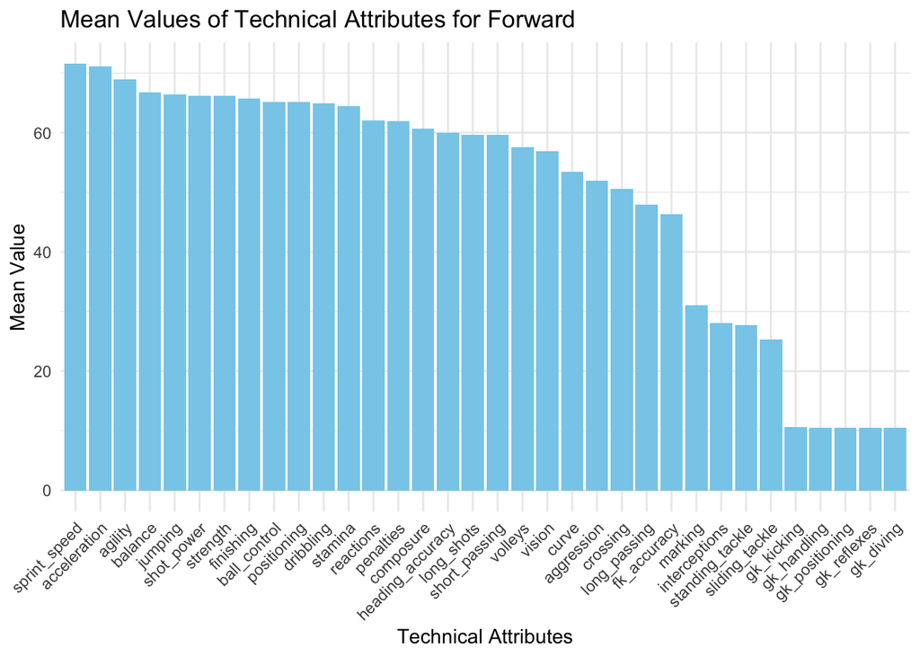

```r
tech_features_1 = tech_features[!tech_features %in% c("skill_moves", "weak_foot")]
for (position in c("Goalkeeper", "Defender", "Midfielder", "Forward")){
    technical_data = numeric_fifa_data[fifa_data$broad_position == position, tech_features_1]
    technical_means = colMeans(technical_data, na.rm = TRUE)
    means_df = data.frame(Column = names(technical_means), Mean = technical_means)

    p = ggplot(means_df, aes(x = reorder(Column, -Mean), y = Mean)) +
      geom_bar(stat = "identity", fill = "skyblue") +
      theme_minimal() +
      labs(title = paste("Mean Values of Technical Attributes for", position),
           x = "Technical Attributes", y = "Mean Value") +
      theme(axis.text.x = element_text(angle = 45, hjust = 1))
    print(p)
}
```

- Từ đồ thị Goalkeeper, ta bỏ cột từ stamina trở đi.
- Hai đồ thị Defender và Midfielder thì bỏ cột liên quan tới GK.
- Còn đồ thị Forward thì bỏ cột marking trở đi.

```r
# Xoá các cột như đồ thị
# Calculate mean threshold of each categories
vision_gk_mean = mean(gk_data$vision, na.rm = TRUE)
sliding_tackle_mid_mean = mean(mid_data$sliding_tackle, na.rm = TRUE)
finishing_df_mean = mean(df_data$finishing, na.rm = TRUE)
fk_accuracy_fw_mean = mean(fw_data$fk_accuracy, na.rm = TRUE)

# Calculate column means for each all columns of each categories and remove those with lower technical mean threshold
gk_means = colMeans(gk_data, na.rm = TRUE)
gk_data = gk_data %>% dplyr::select(-all_of(c(tech_features_1)) | colnames(gk_data[, gk_means >= vision_gk_mean]))

df_means = colMeans(df_data, na.rm = TRUE)
df_data = df_data %>% dplyr::select(-all_of(c(tech_features_1)) | colnames(df_data[, df_means >= finishing_df_mean]))

mid_means = colMeans(mid_data, na.rm = TRUE)
mid_data = mid_data %>% dplyr::select(-all_of(c(tech_features_1))
                                       | colnames(mid_data[, mid_means >= sliding_tackle_mid_mean]))

fw_means = colMeans(fw_data, na.rm = TRUE)
fw_data = fw_data %>% dplyr::select(-all_of(c(tech_features_1)) | colnames(fw_data[, fw_means >= fk_accuracy_fw_mean]))
```

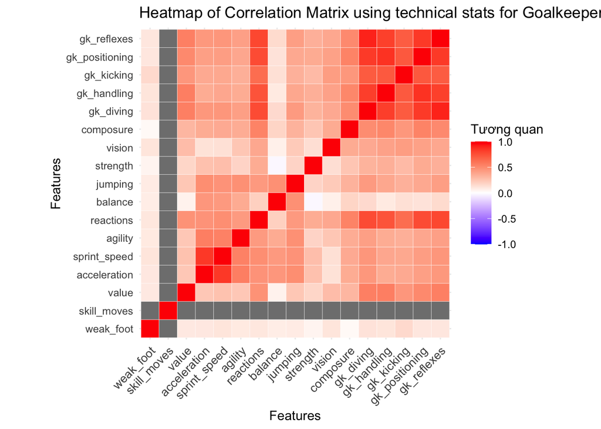

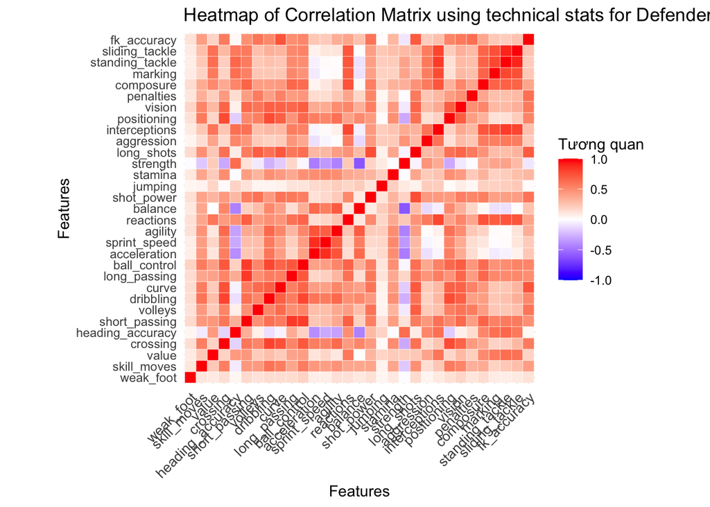

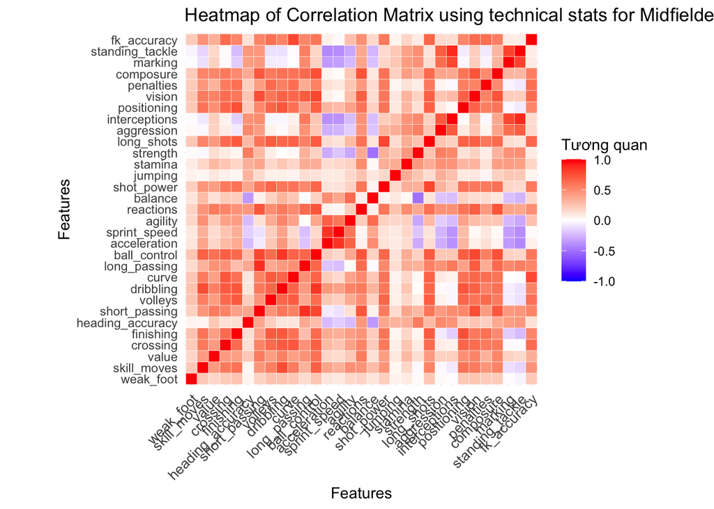

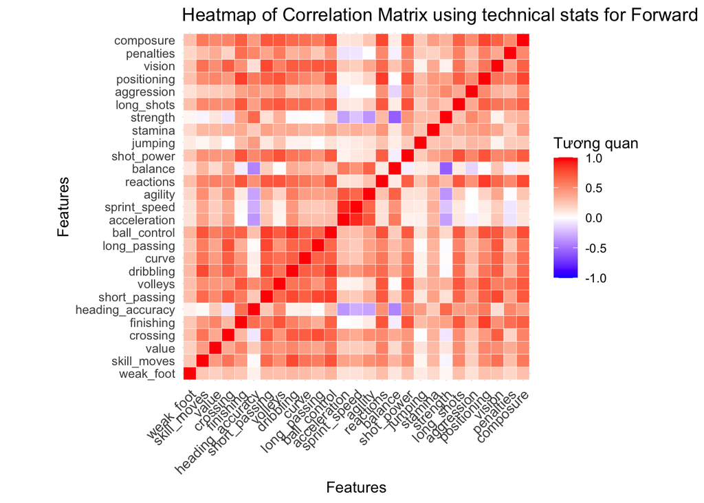

```r
# Plot đồ thị tương quan từng vị trí
data_list = list(gk_data, df_data, mid_data, fw_data)
positions = c("Goalkeeper", "Defender", "Midfielder", "Forward")
for (i in seq_along(data_list)){
  data = data_list[[i]]
  position = positions[[i]]
  correlation_matrix = cor(data, use = "complete.obs")
  # Biểu diễn ma trận tương quan thông số kỹ thuật (demo)
  melted_corr = melt(correlation_matrix)
  p <- ggplot(melted_corr, aes(Var1, Var2, fill = value)) +
    geom_tile(color = "white") +
    scale_fill_gradient2(low = "blue", high = "red", mid = "white",
                         midpoint = 0, limit = c(-1,1), space = "Lab",
                         name="Tương quan") +
    theme_minimal() +
    theme(axis.text.x = element_text(angle = 45, vjust = 1,
                                     size = 10, hjust = 1)) +
    coord_fixed() +
    labs(title = paste("Heatmap of Correlation Matrix using technical stats for", position), x = "Features", y = "Features")
  print(p)
}
```

```r
# Xoá skill_moves
gk_data = gk_data %>% dplyr::select(-skill_moves)
```

#### Kiểm tra đa cộng tuyến

```r
print("GK VIF values")
```

```
## [1] "GK VIF values"
```

```r
print(vif(lm(value ~., data = gk_data)))
```

```
##      weak_foot   acceleration   sprint_speed        agility      reactions
##       1.041981       3.673612       3.586449       1.681994       3.294572
##        balance        jumping       strength         vision      composure
##       1.531013       1.728547       1.224285       1.338197       1.584972
##      gk_diving    gk_handling     gk_kicking gk_positioning    gk_reflexes
##       6.604978       4.768843       2.447355       5.451382       6.684658
```

```r
print("DF VIF values")
```

```
## [1] "DF VIF values"
```

```r
print(vif(lm(value ~., data = df_data)))
```

```
##        weak_foot      skill_moves         crossing heading_accuracy
##         1.050521         1.830597         4.290850         3.313058
##    short_passing          volleys        dribbling            curve
##         5.451868         2.335106         4.944426         3.918187
##     long_passing     ball_control     acceleration     sprint_speed
##         4.098911         5.829290         5.836772         4.677990
##          agility        reactions          balance       shot_power
##         3.428201         4.044386         2.923552         3.159218
##          jumping          stamina         strength       long_shots
##         1.337625         1.745562         2.661033         4.001088
##       aggression    interceptions      positioning           vision
##         2.028766         4.680191         3.596485         3.155650
##        penalties        composure          marking  standing_tackle
##         1.888384         3.359283         3.273299         7.647001
##   sliding_tackle      fk_accuracy
##         6.279069         2.867228
```

```r
print("MID VIF values")
```

```
## [1] "MID VIF values"
```

```r
print(vif(lm(value ~., data = mid_data)))
```

```
##        weak_foot      skill_moves         crossing        finishing
##         1.101881         2.613902         2.893415         3.991879
## heading_accuracy    short_passing          volleys        dribbling
##         2.080580         6.616619         3.180120         6.713456
##            curve     long_passing     ball_control     acceleration
##         3.993471         5.317946         7.776398         4.986861
##     sprint_speed          agility        reactions          balance
##         4.082231         2.976382         3.595317         2.241855
##       shot_power          jumping          stamina         strength
##         3.402134         1.385982         2.017090         2.489434
##       long_shots       aggression    interceptions      positioning
##         4.361568         2.680596         6.304347         3.469107
##           vision        penalties        composure          marking
##         4.299396         2.272225         3.395134         3.166052
##  standing_tackle      fk_accuracy
##         6.411035         3.250596
```

```r
print("FW VIF values")
```

```
## [1] "FW VIF values"
```

```r
print(vif(lm(value ~., data = fw_data)))
```

```
##        weak_foot      skill_moves         crossing        finishing
##         1.141187         2.779014         3.493233         4.773169
## heading_accuracy    short_passing          volleys        dribbling
##         3.835848         5.641951         3.571519         7.170712
##            curve     long_passing     ball_control     acceleration
##         3.065407         3.632745         7.785630         6.441680
##     sprint_speed          agility        reactions          balance
##         5.196496         3.377380         4.414898         2.676725
##       shot_power          jumping          stamina         strength
##         3.961330         1.564424         1.631546         2.857314
##       long_shots       aggression      positioning           vision
##         3.478206         1.885245         5.673463         3.467210
##        penalties        composure
##         1.951638         4.115180
```

```r
mid_data = mid_data %>% dplyr::select(!standing_tackle)
md_mid <- lm(value ~., data = mid_data)
print("VIF MID")
```

```
## [1] "VIF MID"
```

```r
vif(md_mid)
```

```
##        weak_foot      skill_moves         crossing        finishing
##         1.101264         2.611515         2.893331         3.988509
## heading_accuracy    short_passing          volleys        dribbling
##         2.078713         6.592059         3.178358         6.712318
##            curve     long_passing     ball_control     acceleration
##         3.992957         5.258516         7.775775         4.986830
##     sprint_speed          agility        reactions          balance
##         4.082187         2.963121         3.575116         2.241853
##       shot_power          jumping          stamina         strength
##         3.401782         1.384675         2.015790         2.489402
##       long_shots       aggression    interceptions      positioning
##         4.356615         2.606309         4.174053         3.458242
##           vision        penalties        composure          marking
##         4.293983         2.269473         3.392685         2.907062
##      fk_accuracy
##         3.250236
```

#### Chuẩn bị hàm chung

```r
# HÀM ĐÁNH GIÁ MODEL LINEAR, SỬ DỤNG CHUNG
evaluate_model = function(model, train_data, test_data, target_col) {
  predictions = predict(model, newdata = test_data) # lấy tri dự đoán
  actual = test_data[[target_col]] # lấy gtri thực tế

  # Tính RMSE
  rmse = sqrt(mean((actual - predictions)^2, na.rm = TRUE))

  # Tính R2
  rsq = 1 - sum((actual - predictions)^2, na.rm = TRUE) /
              sum((actual - mean(actual, na.rm = TRUE))^2)

  cat("Test results \n")
  cat("RMSE: ", rmse, "\n")
  cat("R2_score: ", rsq, "\n")

  return(list(RMSE = rmse, R2 = rsq))
}
```

```r
# HÀM CHẨN ĐOÁN MÔ HÌNH
model_diagnosis <- function(object){
    # Kiểm tra tính tuyến tính
    p1 <- ggplot(data = object, mapping = aes(x = .fitted, y = .resid)) +
          geom_point() +
          geom_smooth(method = "loess", se = FALSE) +
          geom_hline(yintercept = 0, linetype = "dashed") +
          labs(x = "Fitted values", y = "Residuals", title = "Đồ thị kiểm tra tính tuyến tính mô hình") +
          theme_bw()

    # Kiểm tra tính đồng nhất phương sai
    p2 <- ggplot(data = object, mapping = aes(x = .fitted, y = sqrt(abs(.stdresid)))) +
          geom_point(na.rm = TRUE) +
          geom_smooth(method = "loess", se = FALSE, na.rm = TRUE) +
          labs(x = "Fitted Values",
               y = expression(sqrt("|Standardized residuals|")),
               title = "Đồ thị kiểm tra tính đồng nhất phương sai") +
          theme_bw()

    # Kiểm tra giá trị ngoại lai
    p3 <- ggplot(object, aes(.hat, .stdresid)) +
          geom_point(aes(size = .cooksd)) +
          labs(x = "Leverage", y = "Standardized Residuals", title = "Đồ thị kiểm tra giá trị ngoại lai") +
          scale_size_continuous("Cook's Distance", range = c(1, 6)) +
          theme_bw() +
          theme(legend.position = "bottom")

    print(p1)
    print(p2)
    print(p3)
}
```

#### Mô hình cho MID

```r
set.seed(123) # Đặt seed
split = sample.split(mid_data$value, SplitRatio = 0.7) # 70% train
mid_train = subset(mid_data, split == TRUE)
mid_test = na.omit(subset(mid_data, split == FALSE))
```

```r
# Hàm dự đoán cho regsubsets
predict.regsubsets <- function(object, newdata, id_model, form) {
  x_mat <- model.matrix(form, newdata) # Tạo ma trận model matrix từ dữ liệu mới
  coef_est <- coef(object, id = id_model) # Lấy hệ số ước lượng cho mô hình tại id_model
  x_vars <- names(coef_est) # Tên các biến trong mô hình
  res <- x_mat[, x_vars, drop = FALSE] %*% coef_est # Tính dự đoán bằng ma trận
  return(as.numeric(res)) # Trả về kết quả dự đoán dưới dạng vector
}

# Thiết lập tham số
er_func <- function(data){
  n <- nrow(data) # Số lượng mẫu trong tập train
  n_col <- ncol(data)
  k <- 5 # Số fold
  set.seed(123)

  # Chia k-fold
  folds <- sample(rep(1:k, length.out = n))

  # Tạo ma trận lưu trữ lỗi cho từng fold và từng số lượng biến
  cv <- matrix(0, nrow = k, ncol = n_col - 1)
  formula <- value ~ .

  # Cross-validation
  for (r in 1:k) {
    # Chia dữ liệu thành tập huấn luyện và kiểm tra
    train_r <- data[folds != r, ]
    test_r <- data[folds == r, ]

    # Hồi quy từng bước với regsubsets
    out_subset_folds <- regsubsets(
      formula,
      data = train_r,
      method = "forward",
      nvmax = n_col - 1
    )
    # Dự đoán và tính lỗi cho từng số lượng biến
    for (j in 1:(n_col-1)) {
      pred_rj <- predict.regsubsets(
        object = out_subset_folds,
        newdata = test_r,
        id_model = j,
        form = formula
      )

      cv[r, j] <- sqrt(mean((test_r$value - pred_rj) ^ 2)) # Tính RMSE
    }
  }

  # Tính trung bình lỗi qua các fold
  return(colMeans(cv))
}

er_mid <- er_func(mid_train)
print(er_mid)
```

```
##  [1] 4991405 4878470 4861180 4789130 4789994 4786220 4782229 4773515 4767921
## [10] 4765573 4762955 4760703 4759249 4759411 4757166 4755273 4753051 4751150
## [19] 4751825 4751369 4750779 4751190 4749603 4749815 4750639 4751090 4751199
## [28] 4750725 4750428
```

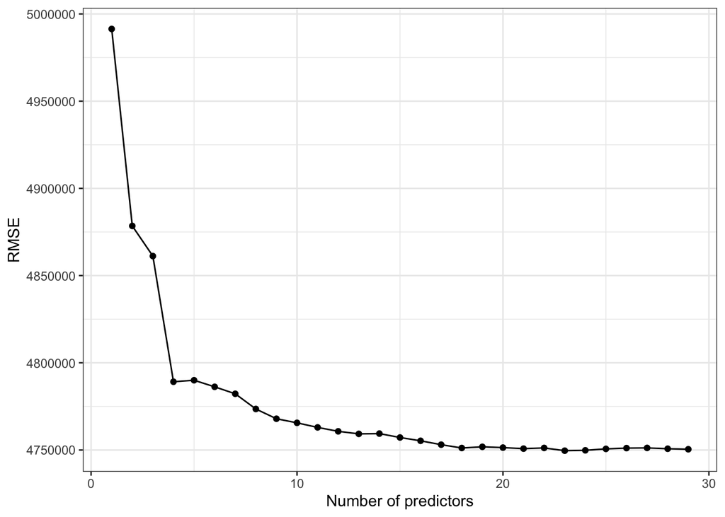

```r
# Tạo data frame với số lượng biến (1:39) và RMSE trung bình
ggplot(data = data.frame(x = 1:29, y = er_mid), mapping = aes(x = x, y = y)) +
  geom_point() +
  geom_line() +
  labs(x = "Number of predictors", y = "RMSE") +
  theme_bw()
```

```r
which.min(er_mid)
```

```
## [1] 23
```

*Với method forward thì model được chọn với 23 biến tốt nhất*

```r
out_subset_train_player <- regsubsets(
  value ~ .,
  data = mid_train,
  nvmax = 23,
  method = "forward"
)

sum_player <- summary(out_subset_train_player)
print(sum_player$cp)
```

```
##  [1] 503.21655 269.57589 209.13800  99.22169  88.96649  78.75765  69.56707
##  [8]  61.54165  43.83293  37.95208  31.63372  28.73248  25.54465  23.86419
## [15]  21.93766  20.61956  20.01440  19.52235  18.11035  18.06756  18.36859
## [22]  19.50892  20.55652
```

```r
selected_vars <- names(coef(out_subset_train_player, 23))[-1]
print(selected_vars)
```

```
##  [1] "weak_foot"     "crossing"      "finishing"     "short_passing"
##  [5] "volleys"       "dribbling"     "curve"         "ball_control"
##  [9] "acceleration"  "sprint_speed"  "agility"       "reactions"
## [13] "jumping"       "stamina"       "strength"      "long_shots"
## [17] "aggression"    "interceptions" "vision"        "penalties"
## [21] "composure"     "marking"       "fk_accuracy"
```

```r
# Model hồi quy với 23 biến được chọn
f_best_mid = as.formula(paste("value ~", paste(selected_vars, collapse = " + ")))
cat("Best Model Formula:\n")
```

```
## Best Model Formula:
```

```r
print(f_best_mid)
```

```
## value ~ weak_foot + crossing + finishing + short_passing + volleys +
##     dribbling + curve + ball_control + acceleration + sprint_speed +
##     agility + reactions + jumping + stamina + strength + long_shots +
##     aggression + interceptions + vision + penalties + composure +
##     marking + fk_accuracy
```

```r
model_mid_av <- lm(f_best_mid, data = mid_train)

# Gọi hàm đánh giá
result_mid = evaluate_model(model = model_mid_av,
                          train_data = mid_train,
                          test_data = mid_test,
                          target_col = "value")
```

```
## Test results
## RMSE:  3628482
## R2_score:  0.47354
```

```r
# Kết quả trả về là danh sách RMSE và R2
print(result_mid)
```

```
## $RMSE
## [1] 3628482
##
## $R2
## [1] 0.47354
```

#### Mô hình cho Goalkeeper

```r
set.seed(123) # Đặt seed
split = sample.split(gk_data$value, SplitRatio = 0.7) # 70% train
gk_train = subset(gk_data, split == TRUE)
gk_test = na.omit(subset(gk_data, split == FALSE))
```

```r
er_gk <- er_func(gk_train)
print(er_gk)
```

```
##  [1] 4332429 4205946 4195232 4175271 4174850 4182181 4185140 4180747 4178826
## [10] 4179716 4178773 4181403 4181133 4183687 4182639
```

```r
print(which.min(er_gk))
```

```
## [1] 5
```

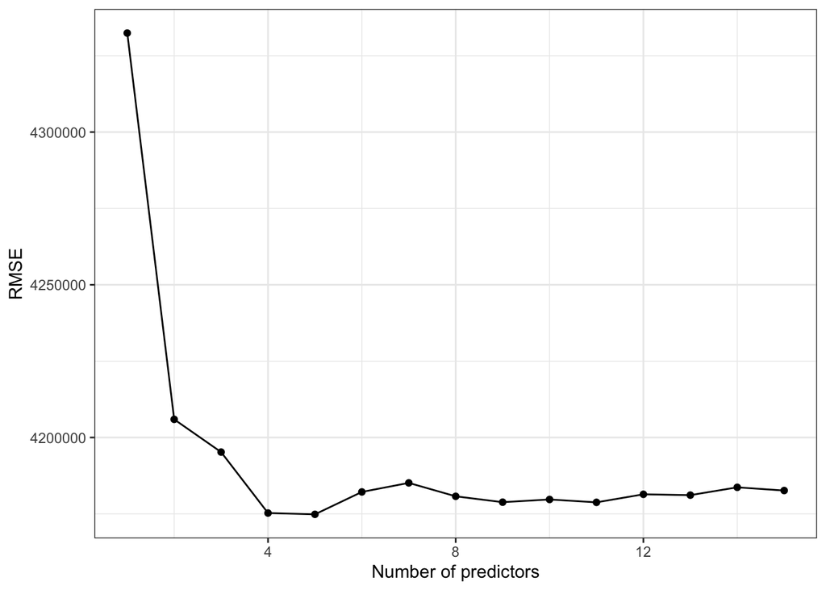

```r
ggplot(data = data.frame(x = 1:length(er_gk), y = er_gk), mapping = aes(x = x, y = y)) +
  geom_point() +
  geom_line() +
  labs(x = "Number of predictors", y = "RMSE") +
  theme_bw()
```

Ta có thể thấy chọn 5 biến là tốt nhất

```r
out_subset_train_player <- regsubsets(
  value ~ .,
  data = gk_train,
  nvmax = 5,
  method = "forward"
)

sum_player <- summary(out_subset_train_player)
print(sum_player$cp)
```

```
## [1] 82.240706 20.831618 13.908824  9.208443  7.652295
```

```r
selected_vars <- names(coef(out_subset_train_player, 5))[-1]
print(selected_vars)
```

```
## [1] "vision"         "gk_diving"      "gk_handling"    "gk_positioning"
## [5] "gk_reflexes"
```

```r
# Model hồi quy với 3 biến được chọn
f_best_gk = as.formula(paste("value ~", paste(selected_vars, collapse = " + ")))
cat("Best Model Formula:\n")
```

```
## Best Model Formula:
```

```r
print(f_best_gk)
```

```
## value ~ vision + gk_diving + gk_handling + gk_positioning + gk_reflexes
```

```r
model_gk_av <- lm(f_best_gk, data = gk_train)

# Gọi hàm đánh giá
result_gk = evaluate_model(model = model_gk_av,
                          train_data = gk_train,
                          test_data = gk_test,
                          target_col = "value")
```

```
## Test results
## RMSE:  2447594
## R2_score:  0.304802
```

```r
# Kết quả trả về là danh sách RMSE và R2
print(result_gk)
```

```
## $RMSE
## [1] 2447594
##
## $R2
## [1] 0.304802
```

R2 = 0.304802 cho thấy model dự đoán không tốt, lệch 2447594 với thực tế của thủ môn.